# Final EDA Assignment

### Life Expectancy with income

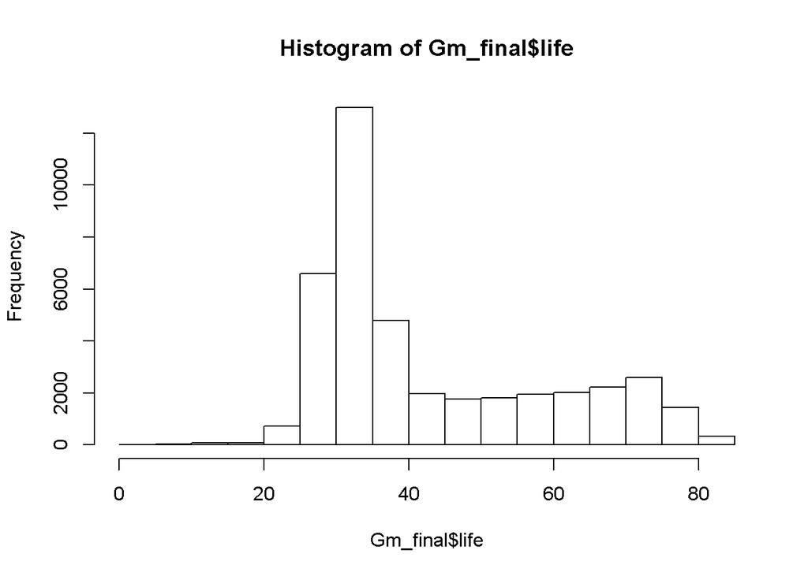

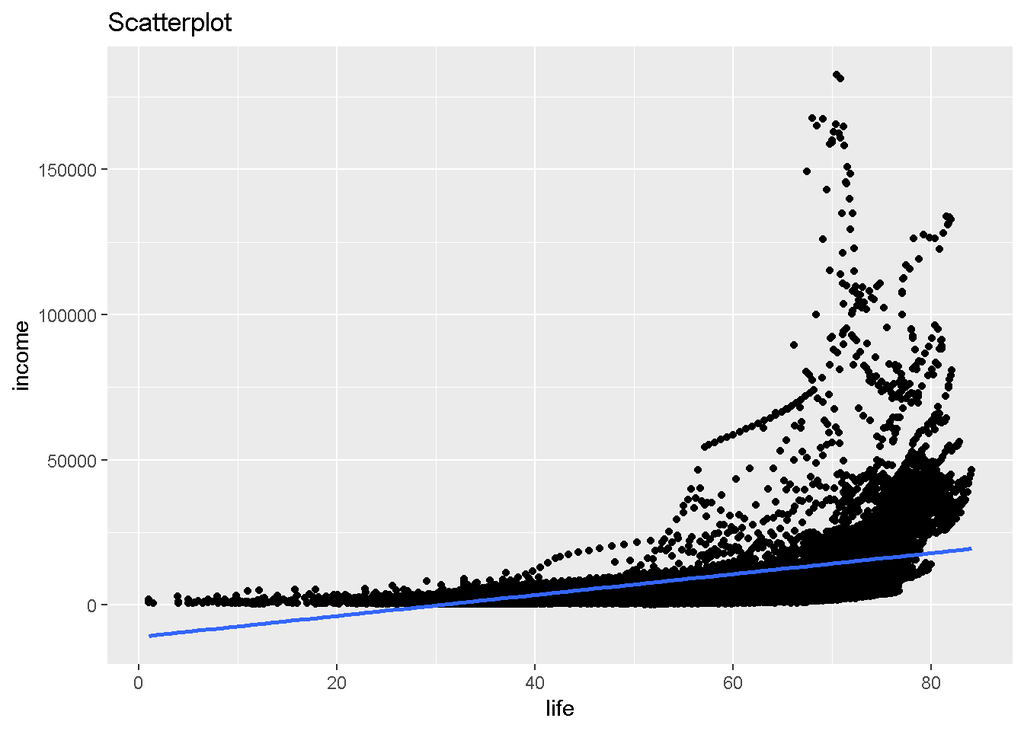

Looking at the histogram , Life expectancy trends to increase after 20 till 35. In other plot we can conclude that life expectancy is increasing regardless of growth in income but EXpectacy level grows above 60 when the income levels increase.

## Regionwise ANalysis

| region | mean | median |
| --- | --- | --- |
| South Asia | 37.42302 | 32.64700 |
| Europe & Central Asia | 48.79419 | 41.74110 |
| Middle East & North Africa | 41.55366 | 32.30000 |
| Sub-Saharan Africa | 37.88242 | 32.40338 |
| America | 44.54065 | 35.37370 |
| East Asia & Pacific | 41.76041 | 34.00000 |

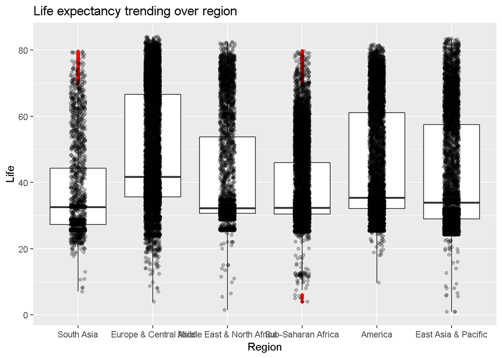

Looking at the Life expectacy trending over region Graph, Europe region has high level of Life Expectacy as compared to our Regions , America and East Asia pacific is also high levl of life expectact.

### income Study

| region | mean | median | min | max |
| --- | --- | --- | --- | --- |
| South Asia | 1384.976 | 1020.0 | 603 | 14408 |
| Europe & Central Asia | 6828.567 | 2735.0 | 393 | 96245 |
| Middle East & North Africa | 8064.382 | 1537.5 | 715 | 182668 |
| Sub-Saharan Africa | 1463.767 | 827.0 | 142 | 40143 |
| America | 4594.560 | 2214.5 | 529 | 53354 |
| East Asia & Pacific | 4411.699 | 1153.5 | 363 | 134864 |

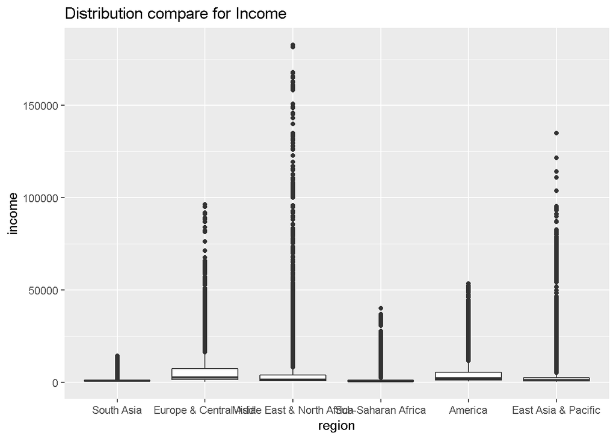

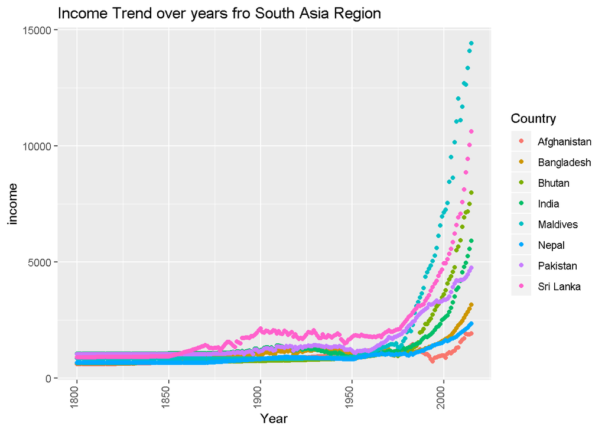

#### Population

| region | max | min |
| --- | --- | --- |
| South Asia | 20.99409 | 10.654385 |
| Europe & Central Asia | 18.81566 | 9.167850 |
| Middle East & North Africa | 18.33194 | 7.933080 |
| Sub-Saharan Africa | 19.02063 | 9.014204 |
| America | 19.58936 | 9.200189 |
| East Asia & Pacific | 21.04248 | 7.344719 |

| region | Total_population |
| --- | --- |
| South Asia | 26819.22 |
| Europe & Central Asia | 155695.06 |
| Middle East & North Africa | 58338.36 |
| Sub-Saharan Africa | 147470.10 |
| America | 107624.97 |
| East Asia & Pacific | 84407.20 |

| region | Total_population | Income |
| --- | --- | --- |
| South Asia | 26819.22 | 2393238 |
| Europe & Central Asia | 155695.06 | 70901008 |
| Middle East & North Africa | 58338.36 | 33096223 |
| Sub-Saharan Africa | 147470.10 | 14860160 |
| America | 107624.97 | 31867866 |
| East Asia & Pacific | 84407.20 | 24881983 |

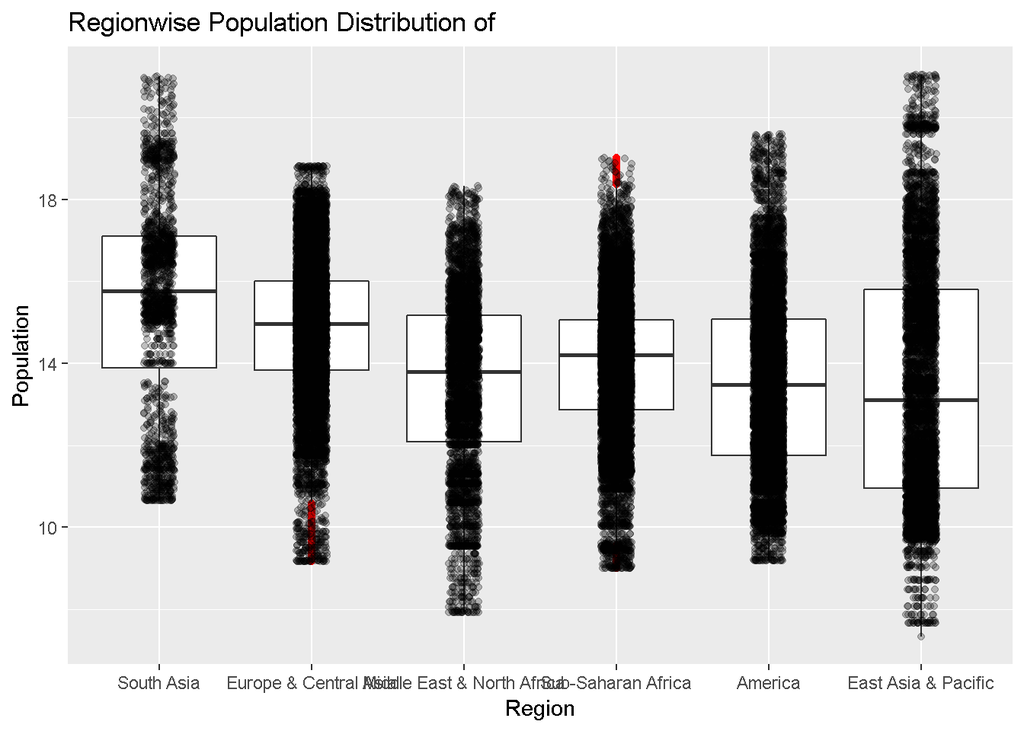

#### Country

[figure not shown]

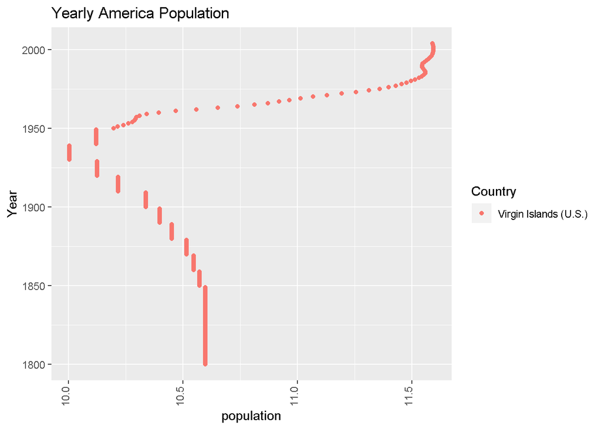

#### Clustering

| Country | Year | life | population | income | region |
| --- | --- | --- | --- | --- | --- |
| Channel Islands | 1950 | 68.516000 | 11.535029 | NA | Europe & Central Asia |
| Channel Islands | 1951 | 68.714000 | 11.542144 | NA | Europe & Central Asia |
| Channel Islands | 1952 | 69.090000 | 11.548804 | NA | Europe & Central Asia |
| Channel Islands | 1953 | 69.425000 | 11.555161 | NA | Europe & Central Asia |
| Channel Islands | 1954 | 69.720000 | 11.561354 | NA | Europe & Central Asia |
| Channel Islands | 1955 | 69.974000 | 11.567489 | NA | Europe & Central Asia |
| Channel Islands | 1956 | 70.190000 | 11.573748 | NA | Europe & Central Asia |
| Channel Islands | 1957 | 70.369000 | 11.580276 | NA | Europe & Central Asia |
| Channel Islands | 1958 | 70.515000 | 11.587216 | NA | Europe & Central Asia |
| Channel Islands | 1959 | 70.636000 | 11.594745 | NA | Europe & Central Asia |

[output cut: 2331 more lines]

```
## List of 9
##  $ cluster     : int [1:38943] 2 2 2 2 2 2 2 2 2 2 ...
##  $ centers     : num [1:5, 1:2] 1994 1823 1953 1913 1868 ...
##   ..- attr(*, "dimnames")=List of 2
##   .. ..$ : chr [1:5] "1" "2" "3" "4" ...
##   .. ..$ : chr [1:2] "Year" "life"
##  $ totss       : num 1.62e+08
##  $ withinss    : num [1:5] 1802878 1588546 1866509 1791889 1535894
##  $ tot.withinss: num 8585716
##  $ betweenss   : num 1.53e+08
##  $ size        : int [1:5] 7795 8260 6896 7912 8080
##  $ iter        : int 3
##  $ ifault      : int 0
##  - attr(*, "class")= chr "kmeans"
```

```
##     life_exp          Country        Income
##  Min.   :-2.9897   Min.   : NA   Min.   :-0.8698
##  1st Qu.:-0.8242   1st Qu.: NA   1st Qu.:-0.7125
##  Median : 0.2232   Median : NA   Median :-0.3235
##  Mean   : 0.0000   Mean   :NaN   Mean   : 0.0000
##  3rd Qu.: 0.7983   3rd Qu.: NA   3rd Qu.: 0.3344
##  Max.   : 1.5854   Max.   : NA   Max.   : 5.8597
##                    NA's   :178
```

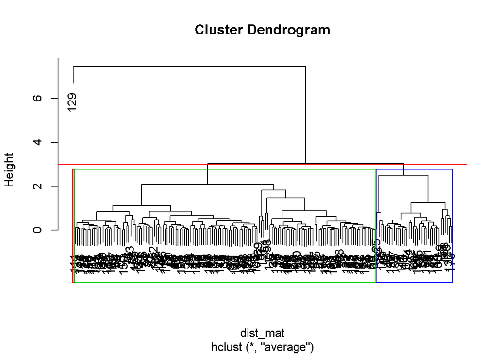